# StatistikEksamen2020

# Eksamensæt 2020

## Opgave 1 – Byen med det første dødsfald i Italien

### a.

Det antages, at det er lige sandsynligt for alle indbyggere at blive smittet, hvilket betyder at sandsynlighederne kan findes som antallet af smittet for hver hændelse ($C$) delt med antallet af indbyggere ($U$). Beregnes dette bliver sandsynligheden for de forskellige hændelser:

[output not shown]

P(C1) = 0.0269697 P(C2) = 0.001818182 P(C3) = 0

[output not shown]

P(C2 | C1) = 0.06741573

[output not shown]

[output not shown]

[output not shown]

P(C1 | S1) = 0.1699346

[output not shown]

0.01007995

[output not shown]

5.05208

[output not shown]

10.39575

[output not shown]

```
[ 0.3037 , 2.9359 ]
```

[output not shown]

eller

[output not shown]

```
[ 1.354863 , 18.83845 ], hvis det skal angives i døgn
```

## Opgave 3 – Udvikling af antal døde i Danmark og Sverige

### a.

Dataene justeres først som ønsket ved at fjerne de første 10 datapunkter, samt at dele antal døde med antal million indbyggere for hvert land.

```
D = read.table("Data_ECEStat_2020_opg3.csv", header=TRUE, sep=";")

popDK = 5.8
popSE = 10.3
start = 11
slut = length(D$Opg3_dagnummer)

X = D$Opg3_dagnummer[11:39]
YDK = D$Opg3_akkum_dk[11:39] / popDK
YSE = D$Opg3_akkum_se[11:39] / popSE

plot(X, YDK, pch = 20, col = "red", main = "Antallet af døde med Covid-19 i 2020", xlab = "Dag numre", ylab = "Antal døde pr. million indbygger")
points(X, YSE, pch = 20, col = "blue")
```

```
legend("topleft", legend=c("Danmark","Sverige"), fill = c("red", "blue"))
```

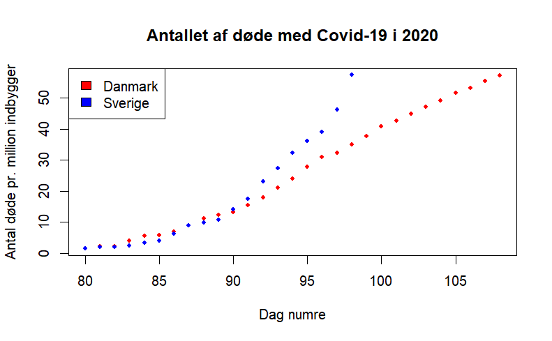

### b.

Lineær regression for Danmark:

```
DagNumre = X
lmDK = lm(YDK ~ DagNumre)
summary(lmDK)
```

```
Call:
lm(formula = YDK ~ DagNumre)

Residuals:
    Min      1Q  Median      3Q     Max
-4.1648 -1.8774  0.5419  1.2487  5.8930

Coefficients:
              Estimate Std. Error t value Pr(>|t|)
(Intercept) -178.59640    5.07183  -35.21   <2e-16 ***
DagNumre       2.17819    0.05374   40.53   <2e-16 ***
---
Signif. codes:  0 ‘***’ 0.001 ‘**’ 0.01 ‘*’ 0.05 ‘.’ 0.1 ‘ ’ 1

Residual standard error: 2.421 on 27 degrees of freedom
Multiple R-squared:  0.9838,    Adjusted R-squared:  0.9832
F-statistic:  1643 on 1 and 27 DF,  p-value: < 2.2e-16
```

Lineær regression for Sverige:

```
lmSE = lm(YSE ~ DagNumre)
summary(lmSE)
```

```
Call:
lm(formula = YSE ~ DagNumre)

Residuals:
    Min      1Q  Median      3Q     Max
-16.632 -12.144  -2.402   6.422  32.256

Coefficients:
             Estimate Std. Error t value Pr(>|t|)
(Intercept) -412.3612    27.9054  -14.78 1.85e-14 ***
DagNumre       4.8742     0.2957   16.48 1.28e-15 ***
---
Signif. codes:  0 ‘***’ 0.001 ‘**’ 0.01 ‘*’ 0.05 ‘.’ 0.1 ‘ ’ 1

Residual standard error: 13.32 on 27 degrees of freedom
Multiple R-squared:  0.9096,    Adjusted R-squared:  0.9063
F-statistic: 271.7 on 1 and 27 DF,  p-value: 1.285e-15
```

Dette resulterer i at modelligningerne for hvert land bliver følgende.

Danmark: $C(t) = 2.1782 t - 178.5964$

Sverige: $C(t) = 4.8742 t - 412.3612$

### c.

Begge modeller passer til en rimelig grad, hvilket kan siges da begge deres p-værdier i meget tæt på 0, og de tilhørende t-værdier viser at koefficienterne er signifikant forskellig fra 0. Den danske model ser ud til at passe bedre da dens $R^2$ værdi er højere end den svenske. Derudover er de justerede $R^2$ værdier også rimelig tæt på de ikke justerede, hvilket tyder på, at der ikke er tale om en overfitted model.

En grund til, at den svenske model ikke passer lige så godt som den danske er at udviklingen ikke foregår lineært. Det kan også ses i grafen fra opgave 3.a, at den svenske graf i modsætning til den danske ser mere eksponentiel ud end lineær.

### d.

[output not shown]

### e.

Lineær regression for Danmark:

```
logDK = log(YDK)
emDK = lm(logDK ~ DagNumre)
summary(emDK)
```

```
Call:
lm(formula = logDK ~ DagNumre)

Residuals:
     Min       1Q   Median       3Q      Max
-0.72891 -0.17007  0.06333  0.25334  0.34500

Coefficients:
             Estimate Std. Error t value Pr(>|t|)
(Intercept) -8.486477   0.664818  -12.77 5.96e-13 ***
DagNumre     0.120684   0.007045   17.13 4.96e-16 ***
---
Signif. codes:  0 ‘***’ 0.001 ‘**’ 0.01 ‘*’ 0.05 ‘.’ 0.1 ‘ ’ 1

Residual standard error: 0.3174 on 27 degrees of freedom
Multiple R-squared:  0.9158,    Adjusted R-squared:  0.9126
F-statistic: 293.5 on 1 and 27 DF,  p-value: 4.955e-16
```

Hvor eksponentialfunktionen til $\log(B)$ giver:

```
BDK = exp(-8.486477)
cat("B =", BDK, "\n")
```

```
B = 0.0002062386
```

Lineær regression for Sverige:

```
logSE = log(YSE)
emSE = lm(logSE ~ DagNumre)
summary(emSE)
```

```
Call:
lm(formula = logSE ~ DagNumre)

Residuals:
    Min      1Q  Median      3Q     Max
-0.4408 -0.3001  0.0823  0.2395  0.3635

Coefficients:
              Estimate Std. Error t value Pr(>|t|)
(Intercept) -12.424655   0.614915  -20.20   <2e-16 ***
DagNumre      0.165289   0.006516   25.37   <2e-16 ***
---
Signif. codes:  0 ‘***’ 0.001 ‘**’ 0.01 ‘*’ 0.05 ‘.’ 0.1 ‘ ’ 1

Residual standard error: 0.2936 on 27 degrees of freedom
Multiple R-squared:  0.9597,    Adjusted R-squared:  0.9582
F-statistic: 643.5 on 1 and 27 DF,  p-value: < 2.2e-16
```

Hvor eksponentialfunktionen til $\log(B)$ giver:

```
BSE = exp(-12.424655)
cat("B =", BSE, "\n")
```

```
B = 4.018286e-06
```

Dette resulterer i at modelligningerne for hvert land bliver følgende.

Danmark: $C(t) = 2.062386 \cdot 10^{-4} \cdot e^{0.120684 t}$

Sverige: $C(t) = 4.018286 \cdot 10^{-6} \cdot e^{0.165289 t}$

### f.

Eksponentiel for Sverige pga. formen på grafen fra opgave 3.a og fordi $R^2$ værdien passer bedre for den ekspnoentielle model ift lineære.

Lineær for Danmark af samme grund, men omvendt da formen på grafen var lineær og den lineære model havde bedre $R^2$ værdi.